# MA [46]15: Lab activity 1

Hongyi Yu

# Introduction

In this lab activity we do a preliminary analysis of global social and economic indices. We use the *Social Progress Index* (SPI) from 2017 and the *Gross Domestic Product* (GDP) per capita from 2018. We downloaded the [social](https://www.socialprogressindex.com/assets/downloads/2017-Results.xlsx.zip) and [economic](http://api.worldbank.org/v2/en/indicator/NY.GDP.PCAP.PP.CD?downloadformat=excel) index data and put them at the `data` folder. We can now load them, along with the `tidyverse` package:

```r
library(tidyverse)
spi <- readxl::read_xlsx("data/2017 Results.xlsx") %>%
  mutate(spi = `Social Progress Index`)
ief <- readxl::read_xls("data/index2018_data.xls") %>%
  mutate(score = as.numeric(`2018 Score`), # Index of Economic Freedom (IEF)
         gdp = as.numeric(`GDP per Capita (PPP)`),
         Region = factor(Region))
```

We can now join the two datasets using `Country`:

```r
(ief.spi <- left_join(select(spi, Country, spi),
                     select(ief, Country, Region, score, gdp)))
```

```
## # A tibble: 236 × 5
##    Country       spi Region                     score    gdp
##    <chr>       <dbl> <fct>                      <dbl>  <dbl>
##  1 Afghanistan  35.7 Asia-Pacific                51.3  1919.
##  2 Albania      71.0 Europe                      64.5 11840.
##  3 Algeria      65.4 Middle East / North Africa  44.7 15026.
##  4 Angola       40.7 Sub-Saharan Africa          48.6  6844.
##  5 Argentina    75.9 Americas                    52.3 20047.
##  6 Armenia      69.0 Europe                      68.7  8621.
##  7 Australia    89.3 Asia-Pacific                80.9 48899.
##  8 Austria      88.0 Europe                      71.8 48005.
##  9 Azerbaijan   65.3 Asia-Pacific                64.3 17439.
## 10 Bangladesh   54.8 Asia-Pacific                55.1  3891.
## # … with 226 more rows
```

# Visualization

Our first visualization is SPI against GDP:

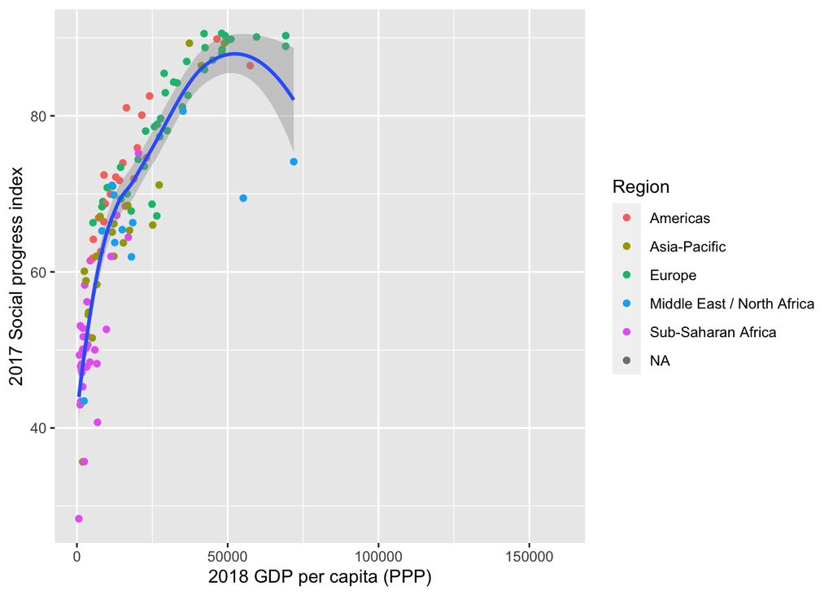

```r
ggplot(ief.spi, aes(gdp, spi)) + geom_point(aes(color = Region)) +
  labs(x = "2018 GDP per capita (PPP)", y = "2017 Social progress index") +
  geom_smooth()
```

Our next visualization plots SPI against IEF:

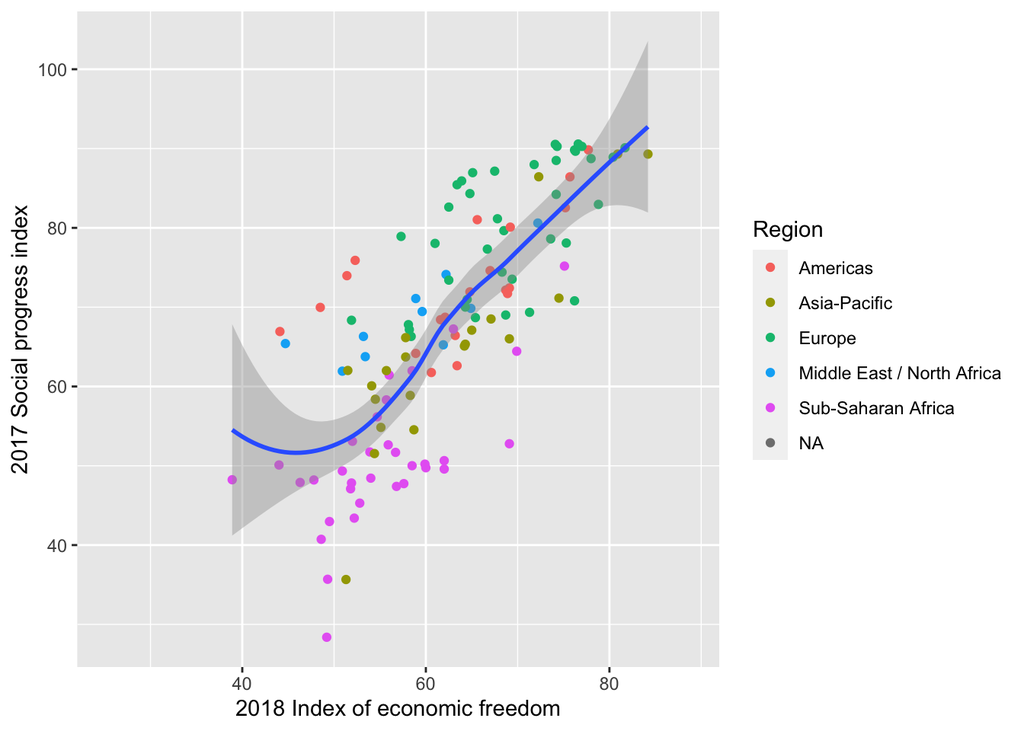

```r
ggplot(ief.spi, aes(score, spi)) + geom_point(aes(color = Region)) +
  labs(x = "2018 Index of economic freedom", y = "2017 Social progress index") +
  geom_smooth()
```

# Discussion

When GDP per capita is smaller than 50000, an increase in GDP per capita is associated with an increase in social progress index. When GDP per capita is greater than 50000, an increase in GDP per capita is associated with a decrease in social progress index.

When index of economic freedom is greater than 45, an increase in index of economic freedom is associated with an increase in social progress index. When index of eonomic freedom is smaller than 45, an increase in index of economic freedom is associated with a decrease in social progress index.